# Reproducible Research: Peer Assessment 1

## Loading and preprocessing the data

```r
#Load data
PAM<-read.csv("activity/activity.csv")
#Convert date from "factor" to "Date" type
PAM$date<-as.Date(PAM$date, format = "%Y-%m-%d")
```

## What is mean total number of steps taken per day?

1. Calculate the total number of steps taken per day

```r
library(dplyr)
PAM_DLY<-na.omit(PAM) %>%
  group_by(date) %>%
  summarise(Sum = sum(steps, na.rm = TRUE))
```

2. Make a histogram of the total number of steps taken each day

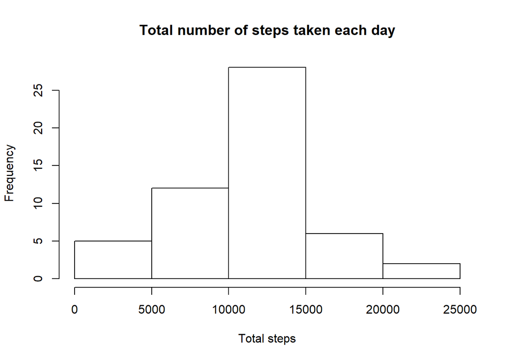

```r
hist(PAM_DLY$Sum, main = "Total number of steps taken each day", xlab = "Total steps")
```

```r
dev.copy(png, file = "TotalStepsEachDay.png", height = 480, width = 480)
```

```r
dev.off()
```

3. Calculate and report the mean and median of the total number of steps taken per day

```r
options(scipen=1, digits=2)
Mean_Dly<-mean(PAM_DLY$Sum)
Median_Dly<-median(PAM_DLY$Sum)
```

- The **mean** of total number of steps taken each day : 10766.19 steps.
- The **median** of total number of steps taken each day: 10765 steps.

## What is the average daily activity pattern?

Lets get the mean number of steps taken per day

```r
PAM_AVG<-PAM %>%
  group_by(interval) %>%
  summarise(Avg = mean(steps, na.rm = TRUE))
```

1. Make a time series plot (i.e. type = “l”) of the 5-minute interval (x-axis) and the average number of steps taken, averaged across all days (y-axis)

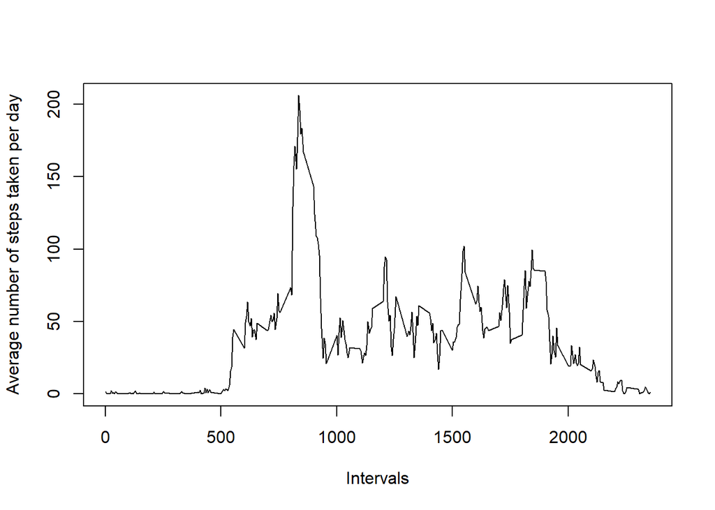

```r
with(PAM_AVG, plot(interval, Avg,
                    type = "l",
                    xlab = "Intervals",
                    ylab = "Average number of steps taken per day"))
```

```r
dev.copy(png, file = "AvgStepsPerDay.png", height = 480, width = 480)
```

```r
dev.off()
```

2. Which 5-minute interval, on average across all the days in the dataset, contains the maximum number of steps?

```r
PAM_AVG_Max<-PAM_AVG$interval[PAM_AVG$Avg == max(PAM_AVG$Avg)]
```

The 835 interval, on average across all the days, contains the maximum number of steps

## Imputing missing values

1. Calculate and report the total number of missing values in the dataset (i.e. the total number of rows with NAs)

```r
nulls<-sum(is.na(PAM))
```

This dataset contains 2304 missing values.

2. Devise a strategy for filling in all of the missing values in the dataset. The strategy does not need to be sophisticated. For example, you could use the mean/median for that day, or the mean for that 5-minute interval, etc.

Lets Update the nulls with the average values of its 5 minute interval average across all days. Using the PAM_AVG data.

3. Create a new dataframe PAM_NoNulls that is equal to the original dataset but with the missing data filled in.

```r
PAM_NoNulls<-PAM %>%
  inner_join(PAM_AVG) %>%
  mutate(steps = coalesce(steps, Avg)) %>%
  select(steps, date, interval)
head(PAM_NoNulls)
```

```
##   steps       date interval
## 1 1.717 2012-10-01        0
## 2 0.340 2012-10-01        5
## 3 0.132 2012-10-01       10
## 4 0.151 2012-10-01       15
## 5 0.075 2012-10-01       20
## 6 2.094 2012-10-01       25
```

4. Histogram of the total number of steps taken each day and Calculate and report the mean and median total number of steps taken per day.

Lets get the mean number of steps taken per day with new dataset.

```r
PAM_DLY1<-PAM_NoNulls %>%
  group_by(date) %>%
  summarise(Sum = sum(steps))
```

Histogram of the total number of steps taken each day

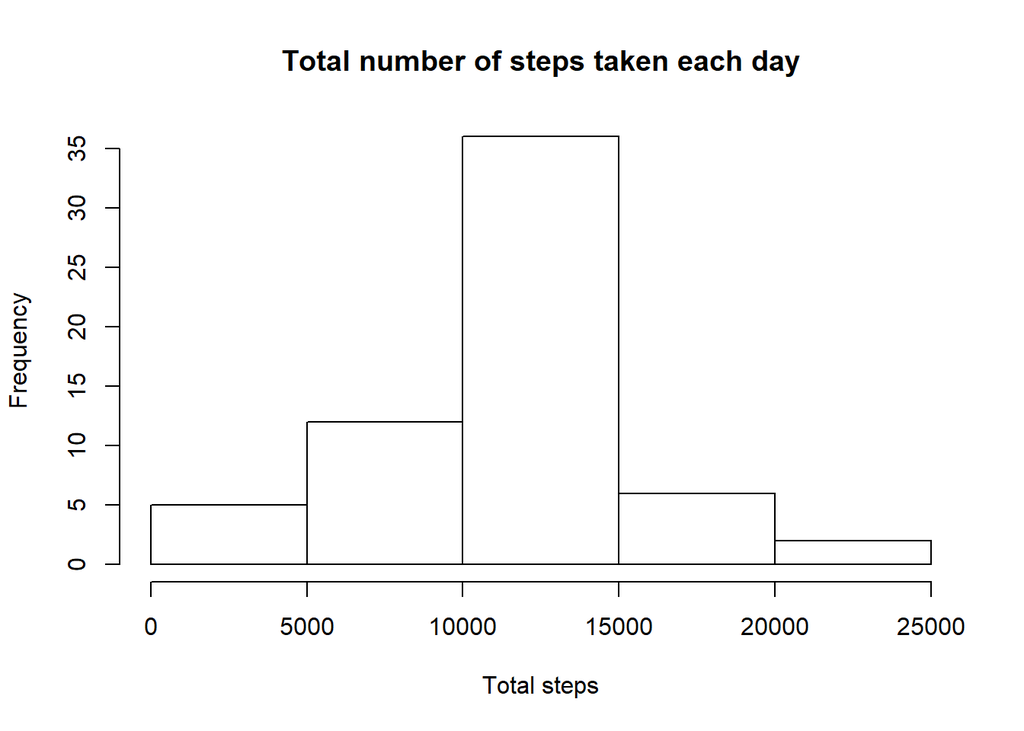

```r
hist(PAM_DLY1$Sum, main = "Total number of steps taken each day", xlab = "Total steps")
```

```r
dev.copy(png, file = "TotalStepsEachDayNoNulls.png", height = 480, width = 480)
```

```r
dev.off()
```

Calculate and report the mean and median total number of steps taken per day.

```r
Mean_Dly1<-mean(PAM_DLY1$Sum)
Median_Dly1<-median(PAM_DLY1$Sum)
```

- The **mean** of total number of steps taken each day after processing NULLS : 10766.19 steps.
- The **median** of total number of steps taken each dayafter processing NULLS : 10766.19 steps.

There is no significant difference with imputing missing values. The overall Mean seem to remain the same. This corelates to the average values of the 5 minute intervals being used to replace NULL values. The median has slightly increased, However, this does not have a major difference.

## Are there differences in activity patterns between weekdays and weekends?

1. Create a new factor variable in the dataset with two levels, *weekday* and *weekend* indicating whether a given date is a weekday or weekend day.

```r
WeekDays<- c('Monday', 'Tuesday', 'Wednesday', 'Thursday', 'Friday')
PAM$IsWeekEnd <- factor((weekdays(PAM$date) %in% WeekDays),
                   levels=c(FALSE, TRUE),
                   labels=c('weekend', 'weekday'))
```

2. Make a panel plot containing a time series plot (i.e. type = “l”) of the 5-minute interval (x-axis) and the average number of steps taken, averaged across all weekday days or weekend days (y-axis).

```r
library(lattice)
PAM_AVG1<-PAM %>%
  group_by(interval, IsWeekEnd) %>%
  summarise(Avg = mean(steps, na.rm = TRUE))
```

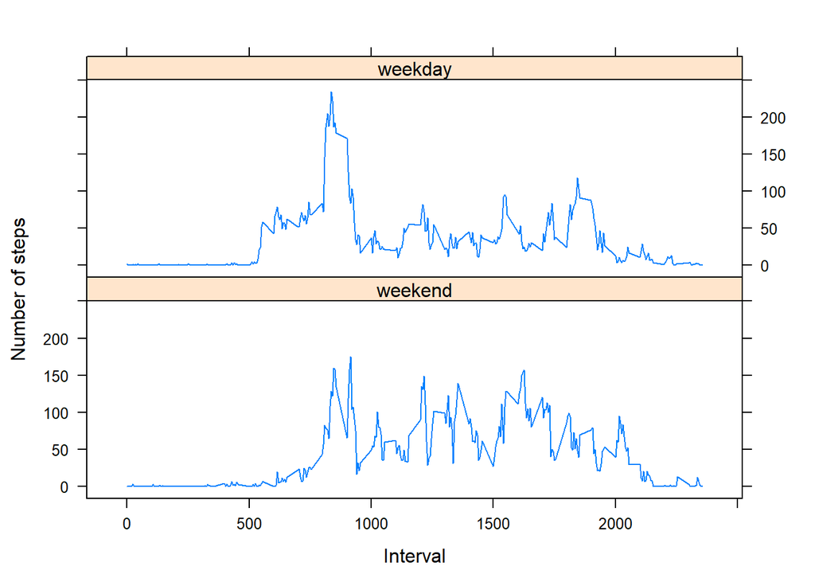

```r
xyplot(Avg ~ interval | IsWeekEnd,
       data = PAM_AVG1,
       layout= c(1,2),
       type = "l",
       ylab = "Number of steps",
       xlab = "Interval")
```

```r
dev.copy(png, file = "StepsForWeekend.png", height = 480, width = 480)
```

```r
dev.off()
```